# Veri Analitiğinin Temelleri

Sude Gül ÜZÜM

## CSV dosyasını ekleme ve Verinin özeti

Bu veri seti, Airline Quality web sitesinden alınan 2023’teki en iyi 10 dereceli havayolunun incelemelerini içerir . İncelemeler, koltuk konforu, personel hizmeti, yiyecek ve içecekler, uçak içi eğlence, paranın karşılığı ve genel derecelendirme dahil olmak üzere uçuş deneyiminin çeşitli yönlerini kapsar.

```
##     Title               Name           Review.Date          Airline
##  Length:8256        Length:8256        Length:8256        Length:8256
##  Class :character   Class :character   Class :character   Class :character
##  Mode  :character   Mode  :character   Mode  :character   Mode  :character
##    Verified           Reviews          Type.of.Traveller  Month.Flown
##  Length:8256        Length:8256        Length:8256        Length:8256
##  Class :character   Class :character   Class :character   Class :character
##  Mode  :character   Mode  :character   Mode  :character   Mode  :character
##     Route              Class           Seat_Comfort       Staff.Service
##  Length:8256        Length:8256        Length:8256        Length:8256
##  Class :character   Class :character   Class :character   Class :character
##  Mode  :character   Mode  :character   Mode  :character   Mode  :character
##  Food...Beverages   Inflight.Entertainment Value.For.Money
##  Length:8256        Length:8256            Length:8256
##  Class :character   Class :character       Class :character
##  Mode  :character   Mode  :character       Mode  :character
##  Overall_Rating     Recommended........
##  Length:8256        Length:8256
##  Class :character   Class :character
##  Mode  :character   Mode  :character
```

## Veri temizleme ve keşifsel veri analizi

Sonuçta veri setimizde eksik değer olmadığı ortaya çıktı.

```
## [1] 0
```

Veri setimiz 8256 satır 17 sütundan oluşmakta.

```
## [1] 8256   17
```

Veri setimizdeki değişkenlerin türleri ve yapıları hakkında bilgiler.

```
## 'data.frame':    8256 obs. of  17 variables:
##  $ Title                 : chr  "Flight was amazing,Alison Soetantyo,2024-03-01,Singapore Airlines,True,\"  Flight was amazing. The crew onboard"| __truncated__ "seats on this aircraft are dreadful " "Food was plentiful and tasty" "“how much food was available,D Laynes,2024-02-19,Singapore Airlin…
##  $ Name                  : chr  "" "Robert Watson" "S Han" "" ...
##  $ Review.Date           : chr  "" "2024-02-21" "2024-02-20" "" ...
##  $ Airline               : chr  "" "Singapore Airlines" "Singapore Airlines" "" ...
##  $ Verified              : chr  "" "True" "True" "" ...
##  $ Reviews               : chr  "" "  Booking an emergency exit seat still meant huge discomfort in a seat far too narrow and poor padding meaning "| __truncated__ "  Excellent performance on all fronts. I would definitely choose to use this airline again. The aircraft is wel"| __truncated__ "" .…
##  $ Type.of.Traveller     : chr  "" "Solo Leisure" "Family Leisure" "" ...
##  $ Month.Flown           : chr  "" "February 2024" "February 2024" "" ...
##  $ Route                 : chr  "" "Phuket to Singapore" "Siem Reap to Singapore" "" ...
##  $ Class                 : chr  "" "Economy Class" "Economy Class" "" ...
##  $ Seat_Comfort          : chr  "" "5" "1" "" ...
##  $ Staff.Service         : chr  "" "3" "5" "" ...
##  $ Food...Beverages      : chr  "" "4" "2" "" ...
##  $ Inflight.Entertainment: chr  "" "4" "1" "" ...
##  $ Value.For.Money       : chr  "" "1" "5" "" ...
##  $ Overall_Rating        : chr  "" "3" "10" "" ...
##  $ Recommended........   : chr  "" "no;;;;;;;;" "yes;;;;;;;;" "" ...
```

```
##  [1] "Title"                  "Name"                   "Review.Date"
##  [4] "Airline"                "Verified"               "Reviews"
##  [7] "Type.of.Traveller"      "Month.Flown"            "Route"
## [10] "Class"                  "Seat_Comfort"           "Staff.Service"
## [13] "Food...Beverages"       "Inflight.Entertainment" "Value.For.Money"
## [16] "Overall_Rating"         "Recommended........"
```

## 1.Uçuş Sınıfına Göre Koltuk Konforu Dağılımı

Amaç: Uçuş sınıfları arasında koltuk konforu puanlarının dağılımı nasıl değiştiğini gösterir.

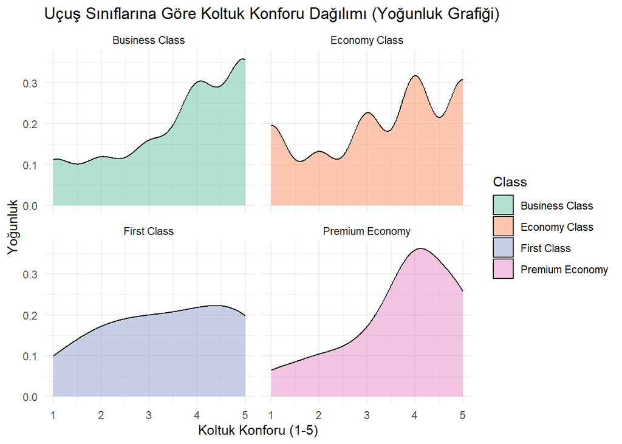

## 2.Havayoluna Göre Koltuk Konforu Ortalaması

Amaç: Hangi havayolunun koltuk konforu puanları daha yüksek?

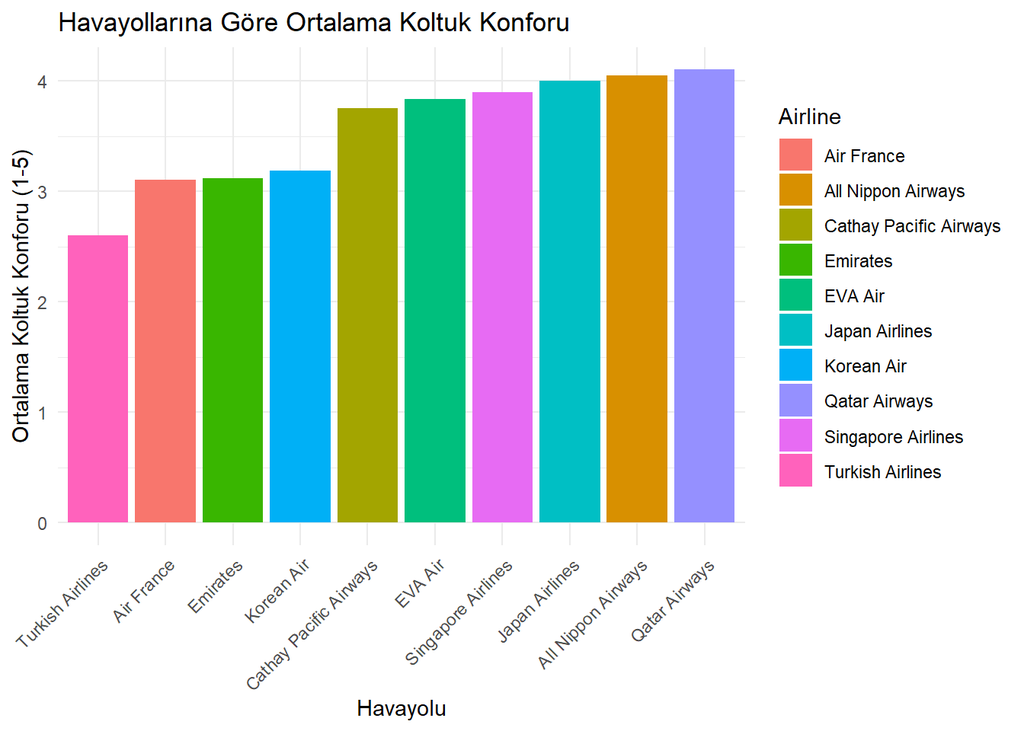

## 3.Havayolu Şirketlerine Göre Koltuk Konforu Karşılaştırması

[figure not shown]

## 4.Yemek Kalitesi ile Genel Memnuniyet İlişkisi

Amaç: Yemek ve içecek kalitesi (Food & Beverages) ile genel memnuniyet arasında ilişki var mı?

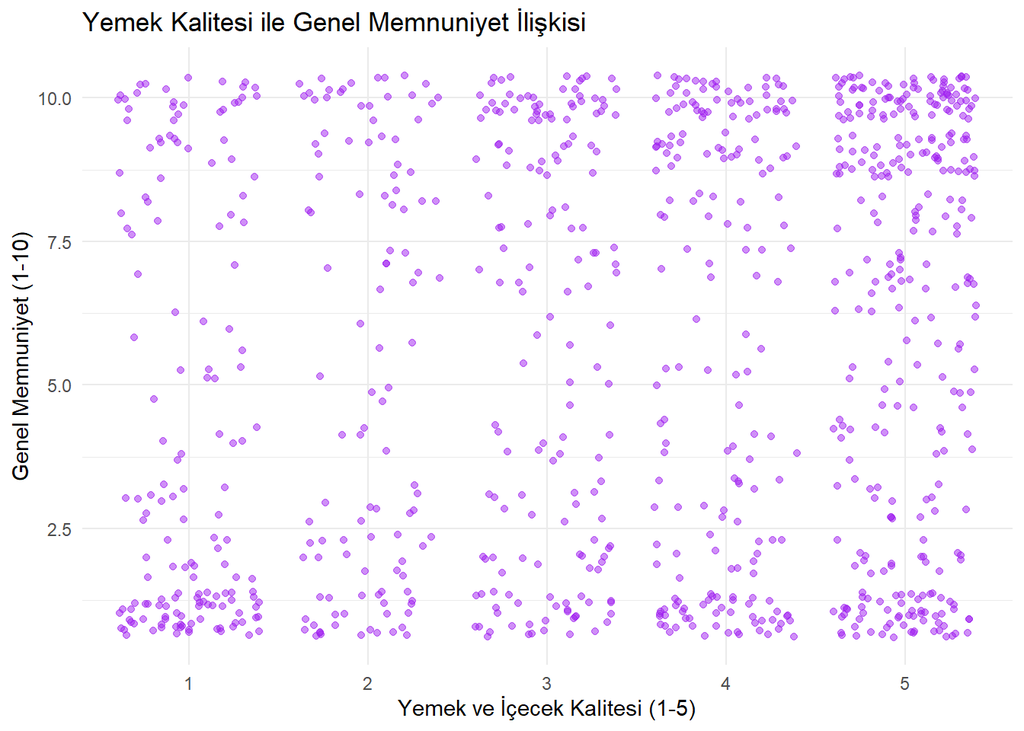

## 5.Uçuş Sınıfına Göre Genel Memnuniyet Dağılımı

Amaç:Bu grafik, uçuş sınıflarına göre genel memnuniyet puanlarının dağılımını gösterir.

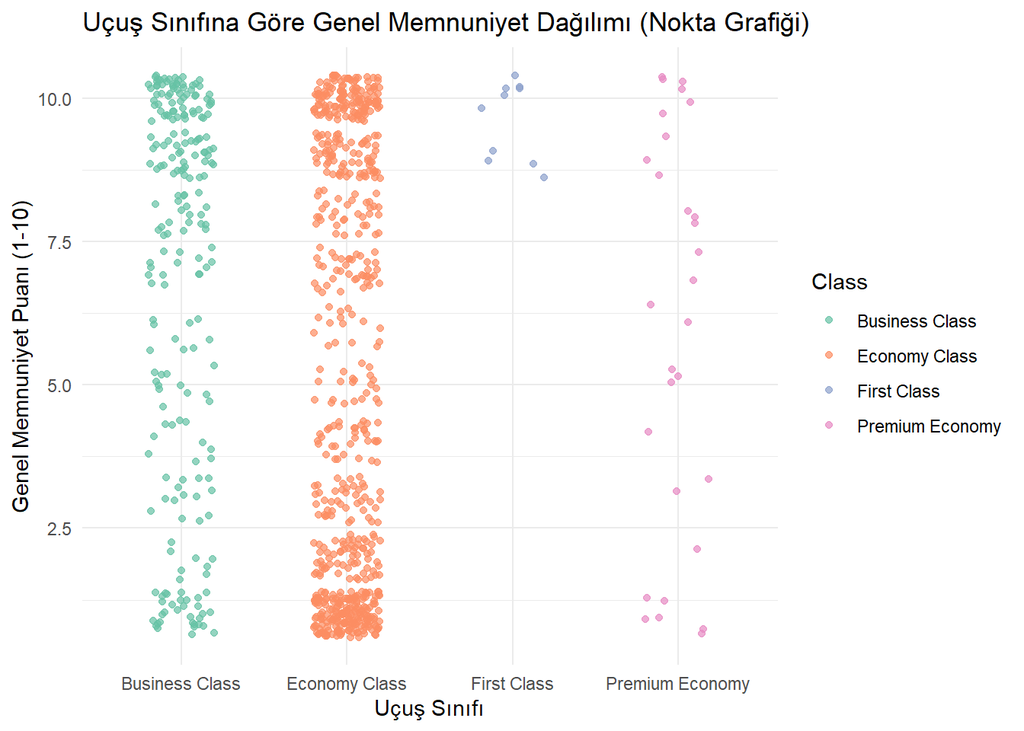

## Regresyon Analizi

Regresyon analizi, bağımlı bir değişken ile bağımsız değişkenler arasındaki ilişkiyi incelemeye yönelik bir yöntemdir. Bu durumda, “Overall_Rating” (Genel Memnuniyet Puanı) bağımlı değişken olarak alınıyor ve “Seat_Comfort”, “Class”, “Airline”, ve “Type.of.Traveller” bağımsız değişkenler olarak kullanılıyor.

```
##
## Call:
## lm(formula = Overall_Rating ~ Seat_Comfort + Class + Airline +
##     Type.of.Traveller, data = veri)
##
## Residuals:
##    Min     1Q Median     3Q    Max
## -7.196 -2.810 -0.033  2.581  7.262
##
## Coefficients:
##                                 Estimate Std. Error t value Pr(>|t|)
## (Intercept)                      5.43165    0.52307  10.384  < 2e-16 ***
## Seat_Comfort                     0.07685    0.08503   0.904 0.366375
## ClassEconomy Class              -1.28720    0.25977  -4.955 8.62e-07 ***
## ClassFirst Class                 2.08968    1.05892   1.973 0.048752 *
## ClassPremium Economy            -1.05208    0.66173  -1.590 0.112205
## AirlineAll Nippon Airways        2.46585    0.80744   3.054 0.002325 **
## AirlineCathay Pacific Airways    0.66337    0.52762   1.257 0.208970
## AirlineEmirates                 -0.42210    0.43229  -0.976 0.329108
## AirlineEVA Air                   2.01324    0.64439   3.124 0.001839 **
## AirlineJapan Airlines            2.17160    0.79136   2.744 0.006187 **
## AirlineKorean Air                1.55552    0.88356   1.761 0.078657 .
## AirlineQatar Airways             2.34065    0.41786   5.601 2.82e-08 ***
## AirlineSingapore Airlines        0.88753    0.45211   1.963 0.049940 *
## AirlineTurkish Airlines         -1.35862    0.40955  -3.317 0.000945 ***
## Type.of.TravellerCouple Leisure  0.03940    0.34427   0.114 0.908906
## Type.of.TravellerFamily Leisure -0.20135    0.35739  -0.563 0.573315
## Type.of.TravellerSolo Leisure    0.94753    0.31449   3.013 0.002659 **
## ---
## Signif. codes:  0 '***' 0.001 '**' 0.01 '*' 0.05 '.' 0.1 ' ' 1
##
## Residual standard error: 3.262 on 909 degrees of freedom
## Multiple R-squared:  0.2222, Adjusted R-squared:  0.2085
## F-statistic: 16.23 on 16 and 909 DF,  p-value: < 2.2e-16
```

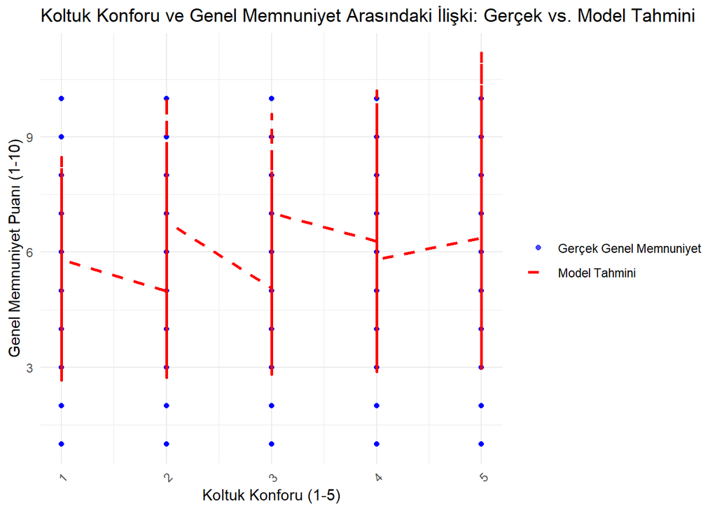

## Sonuçlar ve Yorumlar

Bu çalışmada, uçuş sınıfı, havayolu, yolcu tipi gibi faktörlerin, genel memnuniyet puanları üzerindeki etkisi incelenmiştir. Veri seti üzerinde keşifsel veri analizi yapılmış, görseller oluşturulmuş ve regresyon analizi ile memnuniyetin belirleyicileri hakkında sonuçlar elde edilmiştir. Aşağıda çalışmanın temel bulguları özetlenmiştir:

## 2.Regresyon Analizi

Regresyon analizi yapılarak, Seat_Comfort, Class, Airline gibi bağımsız değişkenlerin Overall_Rating (Genel Memnuniyet Puanı) üzerindeki etkisi incelenmiştir. Modelin özetine göre:

Class değişkeninin etkisi de anlamlıdır, ancak bu etki sınıf türüne göre değişiklik gösterebilir. Örneğin, Business sınıfındaki yolcuların memnuniyeti, ekonomi sınıfına göre daha yüksek olabilir.

Airline değişkeninin genel memnuniyet üzerindeki etkisi istatistiksel olarak anlamlıdır. Farklı havayollarının sunduğu hizmet kalitesi, genel memnuniyeti etkileyebilmektedir.